# DE_analysis_male

Yu (Sylvia) Zhang

2022-11-20

```r
library(GEOquery)
library(SummarizedExperiment)
library(DESeq2)
library(here)
library(dplyr)
library(limma)
library(nlme)
library(MASS)
library(multcomp)
library(pheatmap)
library(variancePartition)
library(lme4)
library("r2glmm")
```

# Load data

I saved the data into a local directory to save time from downloading each time.

```r
gset <- getGEO("GSE48024", GSEMatrix =TRUE, AnnotGPL=TRUE)
save(gset, file = "/Users/yu.zhang/Desktop/BIOS 784/Data/GSE48024/gset.RData")
```

```r
load("/Users/yu.zhang/Desktop/BIOS 784/Data/GSE48024/gset.RData")
```

### Check data

```r
gset_male <- gset[[2]]

length(unique(gset_male$`subject:ch1`))
table(gset_male$`time:ch1`)

male_all4 <- data.frame(table(gset_male$`subject:ch1`)) %>% filter(Freq == 4)

gset_female <- gset[[1]]

length(unique(gset_female$`subject:ch1`))
table(gset_female$`time:ch1`)

female_all4 <- data.frame(table(gset_female$`subject:ch1`)) %>% filter(Freq == 4)
```

# Working on male data

```r
gset_male <- gset[[2]]
```

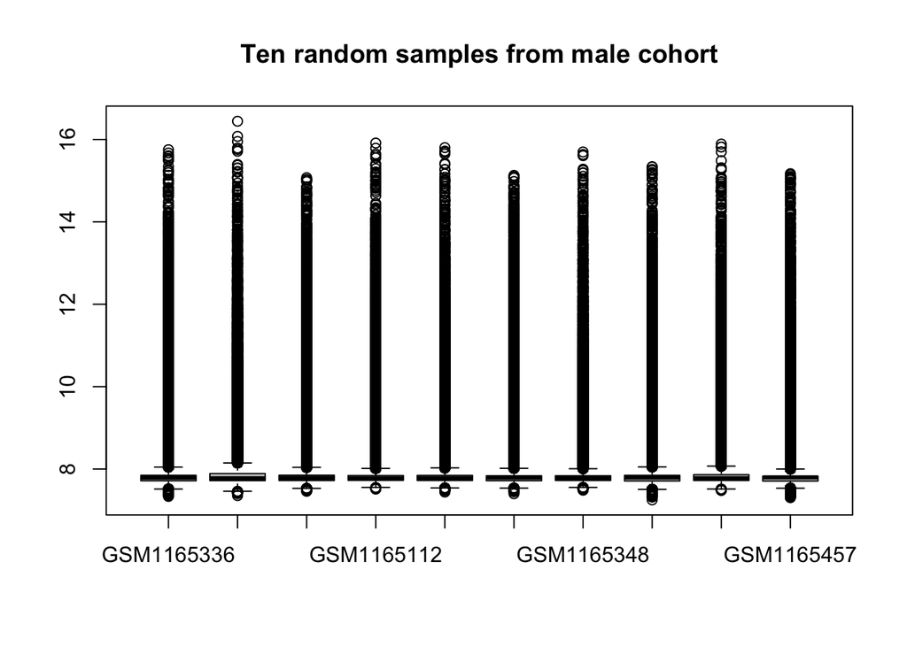

```r
boxplot(exprs(gset_male)[,sample(1:431, 10, replace=F)],
        main = "Ten random samples from male cohort")
```

## Subset to probes with gene name

Total 431 samples and 29228 probes with valid gene symbol.

```r
gset_male <- gset_male[which(gset_male@featureData@data[["Gene symbol"]] != ""), ]

gset_male
```

```
## ExpressionSet (storageMode: lockedEnvironment)
## assayData: 29228 features, 431 samples
##   element names: exprs
## protocolData: none
## phenoData
##   sampleNames: GSM1165057 GSM1165058 ... GSM1165487 (431 total)
##   varLabels: title geo_accession ... treatment:ch1 (41 total)
##   varMetadata: labelDescription
## featureData
##   featureNames: ILMN_1343291 ILMN_1343295 ... ILMN_2416019 (29228
##     total)
##   fvarLabels: ID Gene title ... Platform_SEQUENCE (22 total)
##   fvarMetadata: Column Description labelDescription
## experimentData: use 'experimentData(object)'
##   pubMedIds: 23878721
## 21357945
## Annotation: GPL6947
```

## Set up summarized experiment object

```r
SE_male  <- SummarizedExperiment(assay = list("exprs" = exprs(gset_male)),
                                  colData = as(gset_male@phenoData, "data.frame"),
                                  rowData = as(gset_male@featureData, "data.frame"))

table(SE_male$`time:ch1`)
```

```
##
##  Day0  Day1 Day14  Day3
##   111   110   109   101
```

## Subset to participants sampled at all 4 time points

```r
paticipants.all <- as.data.frame(table(SE_male$`subject:ch1`)) %>% filter(Freq == 4)

SE_male <- SE_male[, which(SE_male$`subject:ch1` %in% paticipants.all$Var1)]

table(SE_male$`time:ch1`)
```

```
##
##  Day0  Day1 Day14  Day3
##    92    92    92    92
```

## Merge duplicate probes, averaging expression from the same gene

Said from limma for averaging expression: “This function should only be applied to normalized log-expression values, and not to raw unlogged expression values. It will generate an error message if applied to RGList or EListRaw objects.”

```r
rownames(SE_male)[1:10]
```

```
##  [1] "ILMN_1343291" "ILMN_1343295" "ILMN_1651209" "ILMN_1651210" "ILMN_1651228"
##  [6] "ILMN_1651229" "ILMN_1651232" "ILMN_1651235" "ILMN_1651237" "ILMN_1651238"
```

```r
expression.dupRM <- avereps(SE_male@assays@data@listData[["exprs"]], ID=SE_male@elementMetadata@listData[["Gene symbol"]])

# match(colnames(expression.dupRM ) , rownames(SE_male@colData))

SE_male_dupRM <- SummarizedExperiment(assay = list("exprs" = expression.dupRM),
                                  colData = SE_male@colData)

SE_male_dupRM
```

```
## class: SummarizedExperiment
## dim: 19589 368
## metadata(0):
## assays(1): exprs
## rownames(19589): EEF1A1 GAPDH ... MCM10 ZNF703
## rowData names(0):
## colnames(368): GSM1165057 GSM1165058 ... GSM1165486 GSM1165487
## colData names(41): title geo_accession ... tissue:ch1 treatment:ch1
```

## Remove lower 25% variant genes

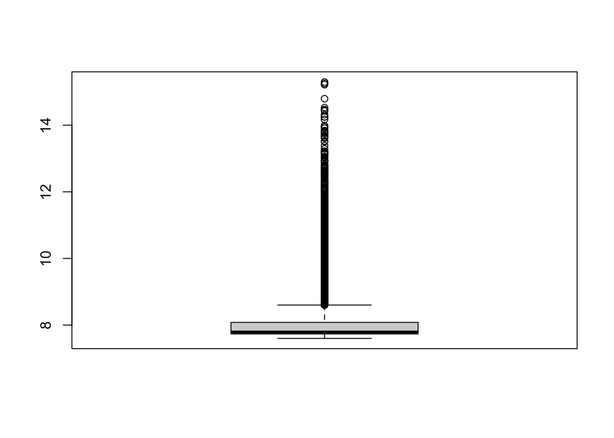

```r
SE_male_dupRM@metadata[["gene_mean"]] <- rowMeans(SE_male_dupRM@assays@data@listData[["exprs"]])

boxplot(SE_male_dupRM@metadata[["gene_mean"]])
```

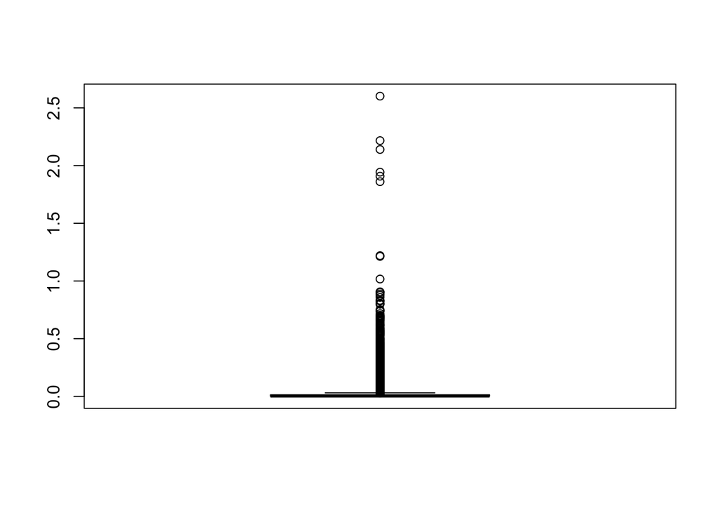

```r
SE_male_dupRM@metadata[["gene_variance"]] <- rowVars(SE_male_dupRM@assays@data@listData[["exprs"]])

boxplot(SE_male_dupRM@metadata[["gene_variance"]])
```

```r
quantile(SE_male_dupRM@metadata[["gene_mean"]]) # 25% = 7.734803
```

```
##        0%       25%       50%       75%      100%
##  7.600727  7.734803  7.792982  8.081913 15.293659
```

```r
quantile(SE_male_dupRM@metadata[["gene_variance"]]) # 25% =  0.0022386139, 75% = 0.0134488159
```

```
##           0%          25%          50%          75%         100%
## 0.0003478975 0.0022386139 0.0039388560 0.0134488159 2.6016623720
```

```r
SE_male_dupRM_25up <- SE_male_dupRM[which(SE_male_dupRM@metadata[["gene_variance"]] > 0.0022386139), ]
SE_male_dupRM_25up
```

```
## class: SummarizedExperiment
## dim: 14692 368
## metadata(2): gene_mean gene_variance
## assays(1): exprs
## rownames(14692): EEF1A1 GAPDH ... MCM10 ZNF703
## rowData names(0):
## colnames(368): GSM1165057 GSM1165058 ... GSM1165486 GSM1165487
## colData names(41): title geo_accession ... tissue:ch1 treatment:ch1
```

```r
#SE_male_dupRM_75up <- SE_male_dupRM[which(SE_male_dupRM@metadata[["gene_variance"]] > 0.0134488159), ]
#SE_male_dupRM_75up

#save(SE_male_dupRM_25up, file = "/Users/yu.zhang/Desktop/BIOS 784/Data/GSE48024/SE_male_dupRM_25up.RData")
#save(SE_male_dupRM_75up, file = "/Users/yu.zhang/Desktop/BIOS 784/Data/GSE48024/SE_male_dupRM_75up.RData")
```

After filtering out lower 25%, we are left with 14692 unique genes and 368 samples.

After filtering out lower 50%, we are left with 9795 unique genes and 368 samples.

After filtering out lower 75%, we are left with 4898 unique genes and 368 samples.

# DE analysis wrt time only

```r
mixed_test <- function(gene,gene_name, covariates, fml, var_rowname){

  df_test <- cbind(gene , covariates)
  colnames(df_test)[1] <- "gene"
  mix_model <- aov(fml, data=df_test)
  df_ret <- data.frame(unlist(summary(mix_model))["Error: Within.Pr(>F)1"])
  rownames(df_ret) <- var_rowname
  colnames(df_ret) <- gene_name
  return(tibble(df_ret))
}

mixed_test2 <- function(gene,gene_name, covariates, fml, var_rowname){

   #gene = as.data.frame(SE_male_dupRM_25up@assays@data@listData[["exprs"]][which(rownames(SE_male_dupRM_25up) ==  genes[1]),])
  #gene_name = genes[1]
  #covariates = cov
  #fml = as.formula(gene ~ time*response + Error(ID))
  #var_rowname = c("response_time")

  df_test <- cbind(gene , covariates)
  colnames(df_test)[1] <- "gene"
  mix_model <- aov(fml, data=df_test)
  df_ret <- data.frame(unlist(summary(mix_model))["Error: Within.Pr(>F)2"])
  rownames(df_ret) <- var_rowname
  colnames(df_ret) <- gene_name
  return(tibble(df_ret))
}
```

## Mixed effect model, gene ~ time + 1|ID

#### P-value from mixed effect model

```r
genes <- rownames(SE_male_dupRM_25up)

cov <- data.frame(ID = SE_male_dupRM_25up$`subject:ch1`,
                  gender = SE_male_dupRM_25up$`gender:ch1`,
                  time = as.character(SE_male_dupRM_25up$`time:ch1`))


mix_test_time <- sapply( 1:nrow(SE_male_dupRM_25up), function(i) mixed_test(   gene = as.data.frame(SE_male_dupRM_25up@assays@data@listData[["exprs"]][which(rownames(SE_male_dupRM_25up) ==  genes[i]),]),
  gene_name = genes[i],
  covariates = cov,
  fml = as.formula(gene ~ time + Error(ID)),
  var_rowname = c("time")) )

mix_test_time <- as.data.frame(unlist(mix_test_time))

colnames(mix_test_time) <- c("p_value_mix_compsym")

write.csv(mix_test_time, file = paste0(here(), "/code/2_DE_analysis/mix_pvalue_compsym.csv"))
```

#### BH-adjusted p-value

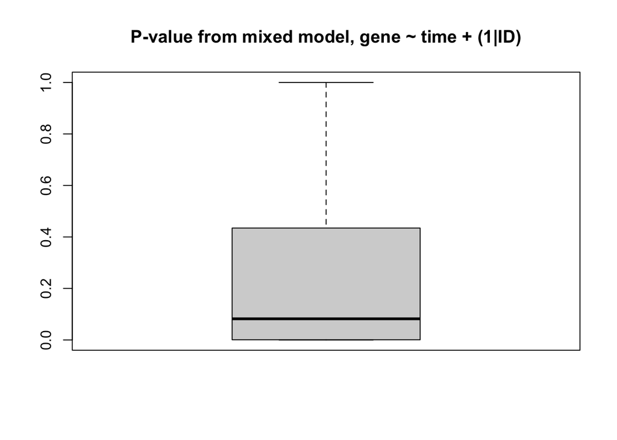

```r
mix_test_time <- read.csv(file = paste0(here(), "/code/2_DE_analysis/mix_pvalue_compsym.csv"))
rownames(mix_test_time) <- mix_test_time$X

boxplot(mix_test_time$p_value_mix_compsym, main ="P-value from mixed model, gene ~ time + (1|ID)")
```

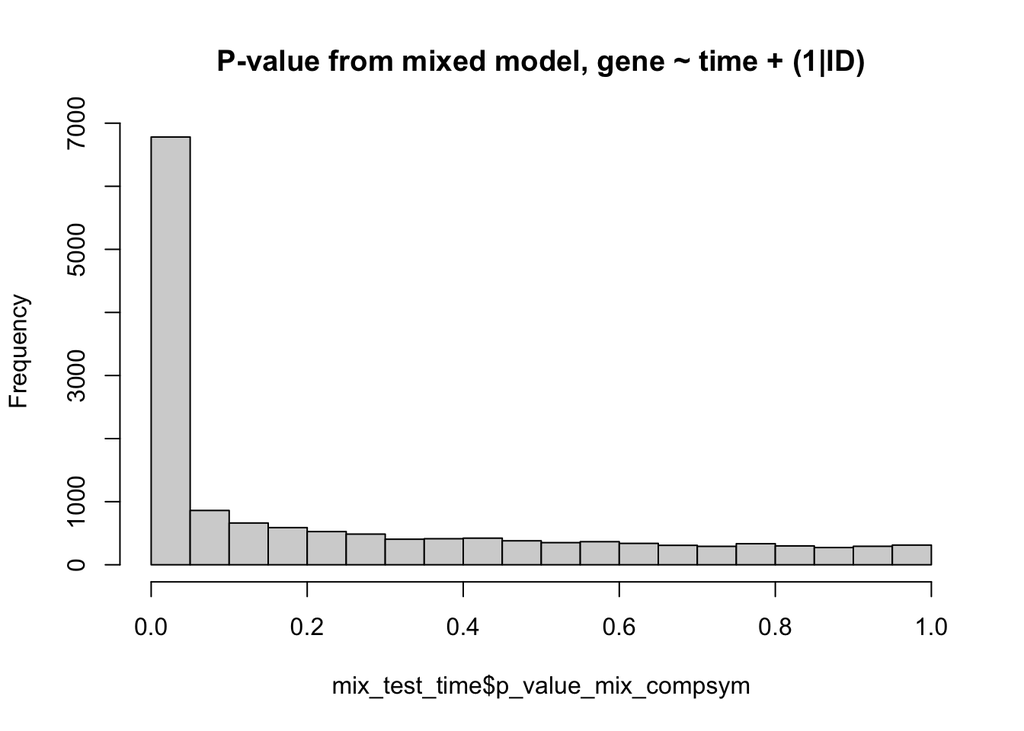

```r
hist(mix_test_time$p_value_mix_compsym, main ="P-value from mixed model, gene ~ time + (1|ID)")
```

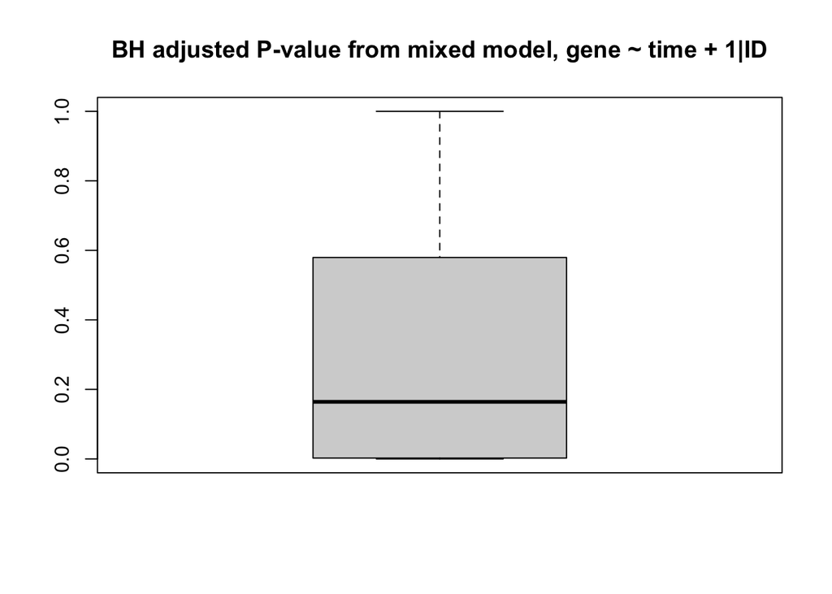

```r
# BH adjusted p-value
mix_test_time$BH_pvalue <- p.adjust(mix_test_time$p_value_mix_compsym, method =  "BH", n = length(mix_test_time$p_value_mix_compsym))

boxplot(mix_test_time$BH_pvalue, main ="BH adjusted P-value from mixed model, gene ~ time + 1|ID")
```

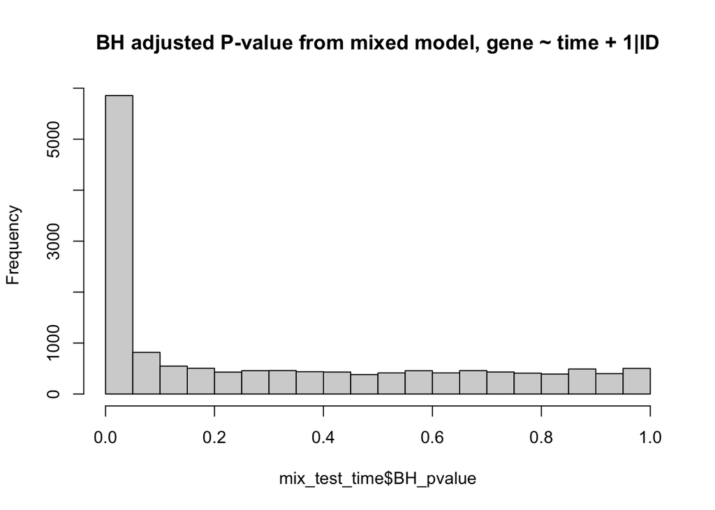

```r
hist(mix_test_time$BH_pvalue, main ="BH adjusted P-value from mixed model, gene ~ time + 1|ID")
```

```r
DEgene_pvalue_BH <- mix_test_time %>% as.data.frame() %>% filter(BH_pvalue < 0.01)

nrow(DEgene_pvalue_BH)
```

```
## [1] 4540
```

A total of 4540 DE genes wrt time after BH adjustment.

#### Heatmap on top 50 DE genes from BH adjusted p-values

```r
DE_genes <- SE_male_dupRM_25up[which(rownames(SE_male_dupRM_25up) %in% rownames(DEgene_pvalue_BH %>% arrange(BH_pvalue))[1:50]), ]

colData(DE_genes)$time <- factor(colData(DE_genes)$`time:ch1`, levels = c("Day0", "Day1", "Day3", "Day14"))

table(colData(DE_genes)$time)
```

```
##
##  Day0  Day1  Day3 Day14
##    92    92    92    92
```

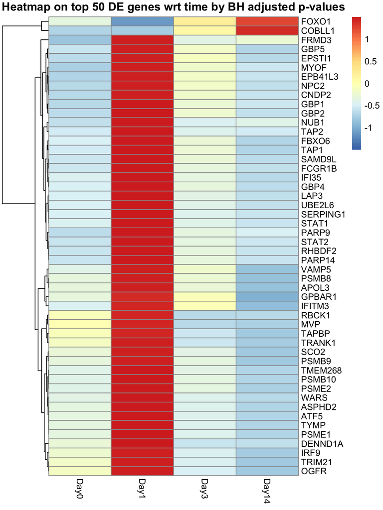

```r
DE_genes_mean <- sapply(c("Day0", "Day1", "Day3", "Day14"), function(day) rowMeans(assay(DE_genes)[, which(colData(DE_genes)$time == day)]))

pheatmap(DE_genes_mean, cluster_rows = TRUE,  cluster_cols = FALSE, scale = "row",
          main = "Heatmap on top 50 DE genes wrt time by BH adjusted p-values")
```

### Gene ontology enrichment analysis

```r
library(enrichplot)
library(DOSE)
library(gprofiler2)

DE_gene_name <- gost(query = DEgene_pvalue_BH$X, organism = "hsapiens", multi_query = FALSE,
                     correction_method = "fdr", user_threshold = 0.01, source = "GO:BP")

head(DE_gene_name$result)
```

```
##     query significant       p_value term_size query_size intersection_size
## 1 query_1        TRUE 2.144710e-102      6522       4004              1829
## 2 query_1        TRUE  2.047788e-82      5462       4004              1543
## 3 query_1        TRUE  1.308116e-69      6309       4004              1680
## 4 query_1        TRUE  1.826354e-69      2842       4004               911
## 5 query_1        TRUE  2.792500e-69      3234       4004              1003
## 6 query_1        TRUE  8.401646e-67      3938       4004              1157
##   precision    recall    term_id source
## 1 0.4567932 0.2804354 GO:1901564  GO:BP
## 2 0.3853646 0.2824973 GO:0019538  GO:BP
## 3 0.4195804 0.2662863 GO:0048518  GO:BP
## 4 0.2275225 0.3205489 GO:0002376  GO:BP
## 5 0.2504995 0.3101422 GO:0044260  GO:BP
## 6 0.2889610 0.2938040 GO:0006950  GO:BP
##                                   term_name effective_domain_size source_order
## 1 organonitrogen compound metabolic process                 21092        24840
## 2                 protein metabolic process                 21092         6764
## 3 positive regulation of biological process                 21092        14820
## 4                     immune system process                 21092         1027
## 5  cellular macromolecule metabolic process                 21092        12680
## 6                        response to stress                 21092         2880
##                              parents
## 1             GO:0006807, GO:0071704
## 2 GO:0043170, GO:0044238, GO:1901564
## 3             GO:0008150, GO:0050789
## 4                         GO:0008150
## 5             GO:0043170, GO:0044237
## 6                         GO:0050896
```

```r
table(DE_gene_name[["result"]][["source"]])
```

```
##
## GO:BP
##  1550
```

```r
#gostplot(DE_gene_name, interactive = TRUE)

colnames(DE_gene_name$result)
```

```
##  [1] "query"                 "significant"           "p_value"
##  [4] "term_size"             "query_size"            "intersection_size"
##  [7] "precision"             "recall"                "term_id"
## [10] "source"                "term_name"             "effective_domain_size"
## [13] "source_order"          "parents"
```

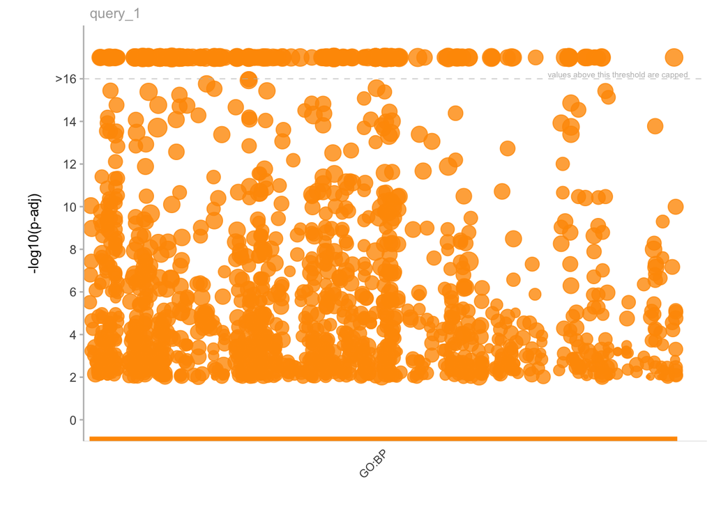

```r
gostplot(DE_gene_name, capped = TRUE, interactive = FALSE)
```

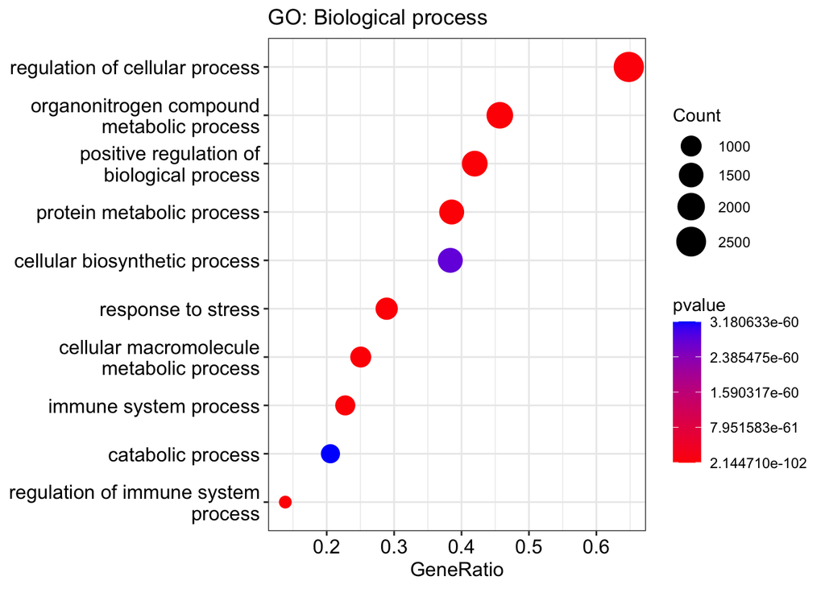

```r
DE_mod = DE_gene_name$result[,c("query",  "term_id",
                                "term_name", "p_value", "query_size",
                                "intersection_size", "term_size",
                                "effective_domain_size", "intersection_size", "source")]

DE_mod$"GeneRatio" = paste0(DE_mod$intersection_size,  "/", DE_mod$query_size)
DE_mod$BgRatio = paste0(DE_mod$term_size, "/", DE_mod$effective_domain_size)
DE_mod$"pvalue" <- DE_mod$p_value
DE_mod$Count <- DE_mod$intersection_size
DE_mod$Description<- DE_mod$term_name
DE_mod_enrich  <-  new("enrichResult", result = DE_mod)

dotplot(DE_mod_enrich , x = 'GeneRatio', color = "pvalue") + ggtitle("GO: Biological process")
```

```r
#BP <-  new("enrichResult", result = DE_mod_enrich@result[which(DE_mod_enrich@result[["source"]] == "GO:BP") , ])

#dotplot(BP , x = 'GeneRatio', color = "pvalue")
```